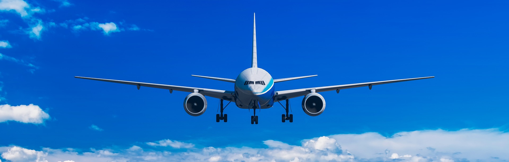

## Travel Package Purchase Prediction

# **General Overview**

### **Background:**

**Visit With Us** a tourism company, wants to build a viable business model that helps you to understand the existing ways of doing the business and how to change the ways for the benefit of the tourism sector.

One of the ways to expand the customer base is to introduce a new offering of packages.

Currently, there are 5 types of packages the company is offering - Basic, Standard, Deluxe, Super Deluxe and King. Looking at the data of the last year, we observed that 18% of the customers purchased the packages.

However, the marketing cost was quite high because customers were contacted at random without looking at the available information.

The company is now planning to launch a new product: **Wellness Tourism Package**. Wellness Tourism is defined as Travel that allows the traveler to maintain, enhance or kick-start a healthy lifestyle, and support or increase one's sense of well-being.

### **Objective:**

The objective is to analyze the customer data and information to provide recommendations to the policymaker and build a model to predict the chances of a potential customer purchasing the newly introduced travel package before the customer is contacted.

### **Key Questions:**

- *What are the different characteristics of the existing customers?*
- *What are the key variables in identifying potential customers for the travel packages?*
- *What is the most important metric and for which model with possible improvements using tuning will give the best results?*

### **Data Description:**

The data contains Customer Details and Customer Interaction Data.

Customer Details:

- **CustomerID:** Unique customer ID
- **ProdTaken:** Whether the customer has purchased a package or not (0: No, 1: Yes)
- **Age:** Age of customer
- **TypeofContact:** How customer was contacted (Company Invited or Self Inquiry)
- **CityTier:** City tier depends on the development of a city, population, facilities, and living standards. The categories are ordered i.e. Tier 1 > Tier 2 > Tier 3. It's the city the customer lives in.
- **Occupation:** Occupation of customer
- **Gender:** Gender of customer
- **NumberOfPersonVisiting:** Total number of persons planning to take the trip with the customer
- **PreferredPropertyStar:** Preferred hotel property rating by customer
- **MaritalStatus:** Marital status of customer
- **NumberOfTrips:** Average number of trips in a year by customer
- **Passport:** The customer has a passport or not (0: No, 1: Yes)
- **OwnCar:** Whether the customers own a car or not (0: No, 1: Yes)
- **NumberOfChildrenVisiting:** Total number of children with age less than 5 planning to take the trip with the customer
- **Designation:** Designation of the customer in the current organization
- **MonthlyIncome:** Gross monthly income of the customer

Cusomer Interaction Data:

- **PitchSatisfactionScore:** Sales pitch satisfaction score
- **ProductPitched:** Product pitched by the salesperson
- **NumberOfFollowups:** Total number of follow-ups has been done by the salesperson after the sales pitch
- **DurationOfPitch:** Duration of the pitch by a salesperson to the customer

# **Sanity Checks**

### **Importing Necessary Libraries**

```python
# Making the Python code more structured automatically
%load_ext nb_black

# Import numpy and pandas: Libraries that handle the reading and manipulating data & numbers
import numpy as np
import pandas as pd

# Import matplotlib & seaborn: Libraries that handle data visualization
import matplotlib.pyplot as plt

%matplotlib inline

import seaborn as sns

sns.set(
    color_codes=True
)  # -----This adds a background color to all the plots created using seaborn

# Allow the use of Display via interactive Python
from IPython.display import display

# Ignore warnings
import warnings

warnings.filterwarnings("ignore")

# Import library for exploratory visualization of missing data.
import missingno as ms

# Removes the limit for the number of displayed columns
pd.set_option("display.max_columns", None)
# Sets the limit for the number of displayed rows
pd.set_option("display.max_rows", 200)

# Import tabulate. library used for creating tables in a visually appealing format.
from tabulate import tabulate

# To split the data into train and test
from sklearn.model_selection import train_test_split

# Library to build Decision Tree classifier
from sklearn.tree import DecisionTreeClassifier
from sklearn import tree

# Library to tune different decision tree models
from sklearn.model_selection import GridSearchCV

# To get diferent metric scores
from sklearn.metrics import (
    f1_score,
    accuracy_score,
    recall_score,
    precision_score,
    confusion_matrix,
    make_scorer,
    roc_auc_score,
    precision_recall_curve,
)

from sklearn import metrics

# Libraries for decision tree classifier and different ensemble classifiers
from sklearn.ensemble import BaggingClassifier
from sklearn.ensemble import RandomForestClassifier
from sklearn.ensemble import AdaBoostClassifier, GradientBoostingClassifier
from xgboost import XGBClassifier
from sklearn.ensemble import StackingClassifier

# Import Permutation Importance for the Important Feature of a Stacking Model
from sklearn.inspection import permutation_importance

# Library for Grid Search Vross-Validation
from sklearn.model_selection import GridSearchCV


print("Loading Libraries... Done.")
```

```
Loading Libraries... Done.
```

### **Loading the Dataset**

```python
# Load the dataset
data_path = "Tourism.xlsx"
df_travel = pd.read_excel(data_path, sheet_name="Tourism")

# copying data to another variable to avoid any changes to original data
df = df_travel.copy()

print("Loading Dataset... Done.")
```

```
Loading Dataset... Done.
```

# **Data Overview**

### **Checking a few rows of the Dataset**

```python
# Checking the top 5, botom 5 and 10 random rows

display(df.head())  # -----looking at head (top 5 observations)
display(df.tail())  # -----looking at tail (bottom 5 observations)
display(
    df.sample(10, random_state=1)
)  # -----15 random sample of observations from the data
```

|  | CustomerID | ProdTaken | Age | TypeofContact | CityTier | DurationOfPitch | Occupation | Gender | NumberOfPersonVisiting | NumberOfFollowups | ProductPitched | PreferredPropertyStar | MaritalStatus | NumberOfTrips | Passport | PitchSatisfactionScore | OwnCar | NumberOfChildrenVisiting | Designation | MonthlyIncome |
| --- | --- | --- | --- | --- | --- | --- | --- | --- | --- | --- | --- | --- | --- | --- | --- | --- | --- | --- | --- | --- |
| 0 | 200000 | 1 | 41.0 | Self Enquiry | 3 | 6.0 | Salaried | Female | 3 | 3.0 | Deluxe | 3.0 | Single | 1.0 | 1 | 2 | 1 | 0.0 | Manager | 20993.0 |
| 1 | 200001 | 0 | 49.0 | Company Invited | 1 | 14.0 | Salaried | Male | 3 | 4.0 | Deluxe | 4.0 | Divorced | 2.0 | 0 | 3 | 1 | 2.0 | Manager | 20130.0 |
| 2 | 200002 | 1 | 37.0 | Self Enquiry | 1 | 8.0 | Free Lancer | Male | 3 | 4.0 | Basic | 3.0 | Single | 7.0 | 1 | 3 | 0 | 0.0 | Executive | 17090.0 |
| 3 | 200003 | 0 | 33.0 | Company Invited | 1 | 9.0 | Salaried | Female | 2 | 3.0 | Basic | 3.0 | Divorced | 2.0 | 1 | 5 | 1 | 1.0 | Executive | 17909.0 |
| 4 | 200004 | 0 | NaN | Self Enquiry | 1 | 8.0 | Small Business | Male | 2 | 3.0 | Basic | 4.0 | Divorced | 1.0 | 0 | 5 | 1 | 0.0 | Executive | 18468.0 |

|  | CustomerID | ProdTaken | Age | TypeofContact | CityTier | DurationOfPitch | Occupation | Gender | NumberOfPersonVisiting | NumberOfFollowups | ProductPitched | PreferredPropertyStar | MaritalStatus | NumberOfTrips | Passport | PitchSatisfactionScore | OwnCar | NumberOfChildrenVisiting | Designation | MonthlyIncome |
| --- | --- | --- | --- | --- | --- | --- | --- | --- | --- | --- | --- | --- | --- | --- | --- | --- | --- | --- | --- | --- |
| 4883 | 204883 | 1 | 49.0 | Self Enquiry | 3 | 9.0 | Small Business | Male | 3 | 5.0 | Deluxe | 4.0 | Unmarried | 2.0 | 1 | 1 | 1 | 1.0 | Manager | 26576.0 |
| 4884 | 204884 | 1 | 28.0 | Company Invited | 1 | 31.0 | Salaried | Male | 4 | 5.0 | Basic | 3.0 | Single | 3.0 | 1 | 3 | 1 | 2.0 | Executive | 21212.0 |
| 4885 | 204885 | 1 | 52.0 | Self Enquiry | 3 | 17.0 | Salaried | Female | 4 | 4.0 | Standard | 4.0 | Married | 7.0 | 0 | 1 | 1 | 3.0 | Senior Manager | 31820.0 |
| 4886 | 204886 | 1 | 19.0 | Self Enquiry | 3 | 16.0 | Small Business | Male | 3 | 4.0 | Basic | 3.0 | Single | 3.0 | 0 | 5 | 0 | 2.0 | Executive | 20289.0 |
| 4887 | 204887 | 1 | 36.0 | Self Enquiry | 1 | 14.0 | Salaried | Male | 4 | 4.0 | Basic | 4.0 | Unmarried | 3.0 | 1 | 3 | 1 | 2.0 | Executive | 24041.0 |

|  | CustomerID | ProdTaken | Age | TypeofContact | CityTier | DurationOfPitch | Occupation | Gender | NumberOfPersonVisiting | NumberOfFollowups | ProductPitched | PreferredPropertyStar | MaritalStatus | NumberOfTrips | Passport | PitchSatisfactionScore | OwnCar | NumberOfChildrenVisiting | Designation | MonthlyIncome |
| --- | --- | --- | --- | --- | --- | --- | --- | --- | --- | --- | --- | --- | --- | --- | --- | --- | --- | --- | --- | --- |
| 3015 | 203015 | 0 | 27.0 | Company Invited | 1 | 7.0 | Salaried | Female | 4 | 6.0 | Basic | 3.0 | Married | 5.0 | 0 | 4 | 1 | 3.0 | Executive | 23042.0 |
| 1242 | 201242 | 0 | 40.0 | Self Enquiry | 3 | 13.0 | Small Business | Male | 2 | 3.0 | King | 4.0 | Single | 2.0 | 0 | 4 | 1 | NaN | VP | 34833.0 |
| 3073 | 203073 | 0 | 29.0 | Self Enquiry | 2 | 15.0 | Small Business | Male | 4 | 5.0 | Basic | 3.0 | Married | 3.0 | 0 | 2 | 0 | 2.0 | Executive | 23614.0 |
| 804 | 200804 | 0 | 48.0 | Company Invited | 1 | 6.0 | Small Business | Male | 2 | 1.0 | Super Deluxe | 3.0 | Single | 3.0 | 0 | 2 | 0 | 0.0 | AVP | 31885.0 |
| 3339 | 203339 | 0 | 32.0 | Self Enquiry | 1 | 18.0 | Small Business | Male | 4 | 4.0 | Deluxe | 5.0 | Divorced | 3.0 | 1 | 2 | 0 | 3.0 | Manager | 25511.0 |
| 3080 | 203080 | 1 | 36.0 | Company Invited | 1 | 32.0 | Salaried | Female | 4 | 4.0 | Basic | 4.0 | Married | 3.0 | 1 | 3 | 0 | 1.0 | Executive | 20700.0 |
| 2851 | 202851 | 0 | 46.0 | Self Enquiry | 1 | 17.0 | Salaried | Male | 4 | 4.0 | Basic | 3.0 | Divorced | 5.0 | 0 | 5 | 1 | 1.0 | Executive | 21332.0 |
| 2883 | 202883 | 1 | 32.0 | Company Invited | 1 | 27.0 | Salaried | Male | 4 | 4.0 | Standard | 3.0 | Divorced | 5.0 | 0 | 3 | 1 | 1.0 | Senior Manager | 28502.0 |
| 1676 | 201676 | 0 | 22.0 | Self Enquiry | 1 | 11.0 | Salaried | Male | 2 | 1.0 | Basic | 4.0 | Married | 2.0 | 1 | 4 | 1 | 0.0 | Executive | 17328.0 |
| 1140 | 201140 | 0 | 44.0 | Self Enquiry | 1 | 13.0 | Small Business | Female | 2 | 3.0 | King | 3.0 | Married | 1.0 | 1 | 4 | 1 | 1.0 | VP | 34049.0 |

*Observations*

- *We will drop `CustomerID` column. It's adding no value to our analysis and models*
- *`ProdTaken` is our target variable and it contains 0s and 1s as should be.*

### **Checking the shape of the dataset**

```python
# -----Print the dimension of the data
print(f"There are {df.shape[0]} rows and {df.shape[1]} columns")
```

```
There are 4888 rows and 20 columns
```

*Observations*

- The dataframe has 4,888 rows and 20 columns

### **Checking the Data Types & General Information of the Dataset**

```python
# -----Displaying information about features of the Dataset
df.info()
```

```
<class 'pandas.core.frame.DataFrame'>
RangeIndex: 4888 entries, 0 to 4887
Data columns (total 20 columns):
 #   Column                    Non-Null Count  Dtype
---  ------                    --------------  -----
 0   CustomerID                4888 non-null   int64
 1   ProdTaken                 4888 non-null   int64
 2   Age                       4662 non-null   float64
 3   TypeofContact             4863 non-null   object
 4   CityTier                  4888 non-null   int64
 5   DurationOfPitch           4637 non-null   float64
 6   Occupation                4888 non-null   object
 7   Gender                    4888 non-null   object
 8   NumberOfPersonVisiting    4888 non-null   int64
 9   NumberOfFollowups         4843 non-null   float64
 10  ProductPitched            4888 non-null   object
 11  PreferredPropertyStar     4862 non-null   float64
 12  MaritalStatus             4888 non-null   object
 13  NumberOfTrips             4748 non-null   float64
 14  Passport                  4888 non-null   int64
 15  PitchSatisfactionScore    4888 non-null   int64
 16  OwnCar                    4888 non-null   int64
 17  NumberOfChildrenVisiting  4822 non-null   float64
 18  Designation               4888 non-null   object
 19  MonthlyIncome             4655 non-null   float64
dtypes: float64(7), int64(7), object(6)
memory usage: 763.9+ KB
```

*Observations*

- *There are missing values in the following columns: `Age`, `TyprofContact`, `DurationOfPitch`, `NumberOfFollowups`, `PreferredPropertyStar`, `NumberOfTrips`, `NumberOfChildrenVisiting`, `MonthlyIncome`.*
- *7 Columns are of type Float, 7 are of type Integer and 6 are of type Object.*

### **Getting the Statistical Summary for the Dataset**

Numerical Variables:

```python
# -----Displaying Statistical Summary of Numerical Data
df.describe().T.round(2)
```

|  | count | mean | std | min | 25% | 50% | 75% | max |
| --- | --- | --- | --- | --- | --- | --- | --- | --- |
| CustomerID | 4888.0 | 202443.50 | 1411.19 | 200000.0 | 201221.75 | 202443.5 | 203665.25 | 204887.0 |
| ProdTaken | 4888.0 | 0.19 | 0.39 | 0.0 | 0.00 | 0.0 | 0.00 | 1.0 |
| Age | 4662.0 | 37.62 | 9.32 | 18.0 | 31.00 | 36.0 | 44.00 | 61.0 |
| CityTier | 4888.0 | 1.65 | 0.92 | 1.0 | 1.00 | 1.0 | 3.00 | 3.0 |
| DurationOfPitch | 4637.0 | 15.49 | 8.52 | 5.0 | 9.00 | 13.0 | 20.00 | 127.0 |
| NumberOfPersonVisiting | 4888.0 | 2.91 | 0.72 | 1.0 | 2.00 | 3.0 | 3.00 | 5.0 |
| NumberOfFollowups | 4843.0 | 3.71 | 1.00 | 1.0 | 3.00 | 4.0 | 4.00 | 6.0 |
| PreferredPropertyStar | 4862.0 | 3.58 | 0.80 | 3.0 | 3.00 | 3.0 | 4.00 | 5.0 |
| NumberOfTrips | 4748.0 | 3.24 | 1.85 | 1.0 | 2.00 | 3.0 | 4.00 | 22.0 |
| Passport | 4888.0 | 0.29 | 0.45 | 0.0 | 0.00 | 0.0 | 1.00 | 1.0 |
| PitchSatisfactionScore | 4888.0 | 3.08 | 1.37 | 1.0 | 2.00 | 3.0 | 4.00 | 5.0 |
| OwnCar | 4888.0 | 0.62 | 0.49 | 0.0 | 0.00 | 1.0 | 1.00 | 1.0 |
| NumberOfChildrenVisiting | 4822.0 | 1.19 | 0.86 | 0.0 | 1.00 | 1.0 | 2.00 | 3.0 |
| MonthlyIncome | 4655.0 | 23619.85 | 5380.70 | 1000.0 | 20346.00 | 22347.0 | 25571.00 | 98678.0 |

*Observations*

- *The average `Age` of a customer is 37.62 and the youngest & oldest are 18 and 61 respectively.*
- *The Average Monthly `Income` of a customer is approximately 23,619.85, with maximum of 98,678. This needs to be verified*
- *Average `DurationOfPitch` is 15 sec to max of 127 sec. (The units in Seconds makes more sense as no one will entertain a sales pitch for 15min and definitely not 127 min (over 2 hours). The unit in hours makes no sense.*
- *Average Number of trips is 3 with maximum of 22. This needs to be verified.*
- *Most of the Customers own a car.*
- *Most of the customers have children*

```python
# Get the Categorical Variables (Object types)
cat_cols = df.select_dtypes(["object"])
cat_cols.columns
```

```
Index(['TypeofContact', 'Occupation', 'Gender', 'ProductPitched',
       'MaritalStatus', 'Designation'],
      dtype='object')
```

```python
# Convert the Object types to Categorical Variables
for i in cat_cols.columns:
    df[i] = df[i].astype("category")
```

```python
df.info()
```

```
<class 'pandas.core.frame.DataFrame'>
RangeIndex: 4888 entries, 0 to 4887
Data columns (total 20 columns):
 #   Column                    Non-Null Count  Dtype
---  ------                    --------------  -----
 0   CustomerID                4888 non-null   int64
 1   ProdTaken                 4888 non-null   int64
 2   Age                       4662 non-null   float64
 3   TypeofContact             4863 non-null   category
 4   CityTier                  4888 non-null   int64
 5   DurationOfPitch           4637 non-null   float64
 6   Occupation                4888 non-null   category
 7   Gender                    4888 non-null   category
 8   NumberOfPersonVisiting    4888 non-null   int64
 9   NumberOfFollowups         4843 non-null   float64
 10  ProductPitched            4888 non-null   category
 11  PreferredPropertyStar     4862 non-null   float64
 12  MaritalStatus             4888 non-null   category
 13  NumberOfTrips             4748 non-null   float64
 14  Passport                  4888 non-null   int64
 15  PitchSatisfactionScore    4888 non-null   int64
 16  OwnCar                    4888 non-null   int64
 17  NumberOfChildrenVisiting  4822 non-null   float64
 18  Designation               4888 non-null   category
 19  MonthlyIncome             4655 non-null   float64
dtypes: category(6), float64(7), int64(7)
memory usage: 564.5 KB
```

Categorical Variables:

```python
# -----Displaying the Summary of Categorical Data
df.describe(include=["category"]).T
```

|  | count | unique | top | freq |
| --- | --- | --- | --- | --- |
| TypeofContact | 4863 | 2 | Self Enquiry | 3444 |
| Occupation | 4888 | 4 | Salaried | 2368 |
| Gender | 4888 | 3 | Male | 2916 |
| ProductPitched | 4888 | 5 | Basic | 1842 |
| MaritalStatus | 4888 | 4 | Married | 2340 |
| Designation | 4888 | 5 | Executive | 1842 |

```python
for i in cat_cols.columns:
    print("Unique values % in", i, "are :")
    print(cat_cols[i].value_counts(normalize=True) * 100)
    print("*" * 50)
    print("\n")
```

```
Unique values % in TypeofContact are :
Self Enquiry       70.820481
Company Invited    29.179519
Name: TypeofContact, dtype: float64


Unique values % in Occupation are :
Salaried          48.445172
Small Business    42.635025
Large Business     8.878887
Free Lancer        0.040917
Name: Occupation, dtype: float64


Unique values % in Gender are :
Male       59.656301
Female     37.172668
Fe Male     3.171031
Name: Gender, dtype: float64


Unique values % in ProductPitched are :
Basic           37.684124
Deluxe          35.433715
Standard        15.180033
Super Deluxe     6.996727
King             4.705401
Name: ProductPitched, dtype: float64


Unique values % in MaritalStatus are :
Married      47.872340
Divorced     19.435352
Single       18.739771
Unmarried    13.952537
Name: MaritalStatus, dtype: float64


Unique values % in Designation are :
Executive         37.684124
Manager           35.433715
Senior Manager    15.180033
AVP                6.996727
VP                 4.705401
Name: Designation, dtype: float64
```

*Observations*

- *`Unmarried` here would means customers having partners...this has be distinguished from the `Single` category.*
- *`Female` and `Fe male` are same category, this needs to be fixed.*
- *Over 70% `TypeofContact` are Self Enquiries. The business can maximize this by increasing it's visibility and channels of enquiry.

### **Checking Missing & Duplicate Values**

```python
# Checking missing values across each columns

c_missing = pd.Series(df.isnull().sum(), name="Missing Count")  # -----Count Missing

p_missing = pd.Series(
    round(df.isnull().sum() / df.shape[0] * 100, 2), name="% Missing"
)  # -----Percentage Missing


# Combine into 1 Dataframe
missing_df = pd.concat([c_missing, p_missing], axis=1)

# # Display missing info
# display(missing_df)

missing_df.sort_values(by="% Missing", ascending=False).style.background_gradient(
    cmap="YlOrRd"
)
```

|  | Missing Count | % Missing |
| --- | --- | --- |
| DurationOfPitch | 251 | 5.140000 |
| MonthlyIncome | 233 | 4.770000 |
| Age | 226 | 4.620000 |
| NumberOfTrips | 140 | 2.860000 |
| NumberOfChildrenVisiting | 66 | 1.350000 |
| NumberOfFollowups | 45 | 0.920000 |
| PreferredPropertyStar | 26 | 0.530000 |
| TypeofContact | 25 | 0.510000 |
| Designation | 0 | 0.000000 |
| OwnCar | 0 | 0.000000 |
| PitchSatisfactionScore | 0 | 0.000000 |
| Passport | 0 | 0.000000 |
| CustomerID | 0 | 0.000000 |
| MaritalStatus | 0 | 0.000000 |
| ProdTaken | 0 | 0.000000 |
| NumberOfPersonVisiting | 0 | 0.000000 |
| Gender | 0 | 0.000000 |
| Occupation | 0 | 0.000000 |
| CityTier | 0 | 0.000000 |
| ProductPitched | 0 | 0.000000 |

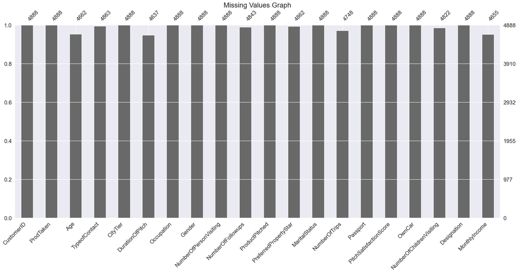

```python
# Visual Exploration of Missing Values
# Plot missing values across each columns
plt.title("Missing Values Graph", fontsize=20)
ms.bar(df)
```

*Observations*

- *All the Columns have less than 6% missing values*
- *5% values are missing in `DurationOfPitch`, that may be cause customer was never pitched, need to analyze further.*
- *4.77% values are missig from `MonthlyIncome`.*
- *`Age` has 4.62% missing values.*
- *`NumberOfChildrenVisiting`, `NumberOfFollowups`, `NumberOfTrips`, `PreferredPropertyStar`, `TypeofContact` all have less than 3% missing values.*

```python
# Checking for duplicate records

df.duplicated().sum()
```

```
0
```

*Observations*

- *There are no duplicate values.*

# **Data Preprocessing**

### **Fixing Gender Value**

```python
df.Gender.value_counts()
```

```
Male       2916
Female     1817
Fe Male     155
Name: Gender, dtype: int64
```

```python
# Replace 'Fe male' with 'Female'
df["Gender"] = df["Gender"].apply(lambda x: "Female" if x == "Fe Male" else x)

# Convert Gender back to Category
df["Gender"] = df["Gender"].astype("category")
```

```python
df.Gender.value_counts()
```

```
Male      2916
Female    1972
Name: Gender, dtype: int64
```

- *'Fe male' has been successfully converted to 'Female'*

### **Dropping Column**

```python
# --------------------
# Dropping CustomerID Column as it will not be contributing to our analysis in any way
# --------------------

df.drop("CustomerID", axis="columns", inplace=True)
```

```python
# Display Info and Shape of the dataframe, confirming the deleted ID column

display(df.shape)
df.info()
```

```
(4888, 19)
```

```
<class 'pandas.core.frame.DataFrame'>
RangeIndex: 4888 entries, 0 to 4887
Data columns (total 19 columns):
 #   Column                    Non-Null Count  Dtype
---  ------                    --------------  -----
 0   ProdTaken                 4888 non-null   int64
 1   Age                       4662 non-null   float64
 2   TypeofContact             4863 non-null   category
 3   CityTier                  4888 non-null   int64
 4   DurationOfPitch           4637 non-null   float64
 5   Occupation                4888 non-null   category
 6   Gender                    4888 non-null   category
 7   NumberOfPersonVisiting    4888 non-null   int64
 8   NumberOfFollowups         4843 non-null   float64
 9   ProductPitched            4888 non-null   category
 10  PreferredPropertyStar     4862 non-null   float64
 11  MaritalStatus             4888 non-null   category
 12  NumberOfTrips             4748 non-null   float64
 13  Passport                  4888 non-null   int64
 14  PitchSatisfactionScore    4888 non-null   int64
 15  OwnCar                    4888 non-null   int64
 16  NumberOfChildrenVisiting  4822 non-null   float64
 17  Designation               4888 non-null   category
 18  MonthlyIncome             4655 non-null   float64
dtypes: category(6), float64(7), int64(6)
memory usage: 526.3 KB
```

*Observations*

### **Missing Value Treatment**

*Missing Value Treatment for the only Categorical Column*

- We will impute the missing value for `TypeofContact` using the mode(highest occuring value) of the feature. Highest ocurring value is `Self Inquiry`.

```python
# Check the number of Missing Values
df["TypeofContact"].isnull().sum()
```

```
25
```

```python
# Treat the missing Values with the Mode
df["TypeofContact"] = df["TypeofContact"].fillna("Self Enquiry")
```

```python
# Verify if there are still Missing Values
df["TypeofContact"].isnull().sum()
```

```
0
```

*Missing Value Treatment for Numerical Columns*

`Age` and `MonthlyIncome` are usually linked to `Designation` and since there are no missing values in Designation we can use it as a basis to update the missing values in `Age` and `MonthlyIncome`.

```python
# Replace the missing values with median Income w.r.t the customer's designation
df["MonthlyIncome"] = df.groupby(["Designation"])["MonthlyIncome"].transform(
    lambda x: x.fillna(x.median())
)

# Replace the missing values with median Age w.r.t the customer's designation
df["Age"] = df.groupby(["Designation"])["Age"].transform(lambda x: x.fillna(x.median()))
```

Missing Value Treatment for the other Numerical Variables

```python
# Create a list of numerical columns with missing values (apart from Age & MonthlyIncome)
missing_numerical = [
    "DurationOfPitch",
    "NumberOfTrips",
    "NumberOfChildrenVisiting",
    "NumberOfFollowups",
    "PreferredPropertyStar",
]

# Function for replacing with the Median value of the columns
medianFiller = lambda x: x.fillna(x.median())

# Applying the function...
df[missing_numerical] = df[missing_numerical].apply(medianFiller, axis=0)
```

```python
# Count of null records
df.isna().sum()
```

```
ProdTaken                   0
Age                         0
TypeofContact               0
CityTier                    0
DurationOfPitch             0
Occupation                  0
Gender                      0
NumberOfPersonVisiting      0
NumberOfFollowups           0
ProductPitched              0
PreferredPropertyStar       0
MaritalStatus               0
NumberOfTrips               0
Passport                    0
PitchSatisfactionScore      0
OwnCar                      0
NumberOfChildrenVisiting    0
Designation                 0
MonthlyIncome               0
dtype: int64
```

*Observations*

- *There are no more missing values*

### **Pre-EDA Data Wrangling**

Income and Age can be a vital factors in tourism. Creating Categorical Bins to explore can reveal interesting insights and useful Customer segmentations and patterns.

```python
df[["Age", "MonthlyIncome"]].describe().T
```

|  | count | mean | std | min | 25% | 50% | 75% | max |
| --- | --- | --- | --- | --- | --- | --- | --- | --- |
| Age | 4888.0 | 37.429828 | 9.149822 | 18.0 | 31.0 | 36.0 | 43.00 | 61.0 |
| MonthlyIncome | 4888.0 | 23546.843903 | 5266.279293 | 1000.0 | 20485.0 | 22413.5 | 25424.75 | 98678.0 |

```python
# Creating Categorical Bins from Age and Monthly Income to analyze,
# to explore can reveal interesting insights and useful Customer segmentations and patterns.

df["Age_Bin"] = pd.cut(
    x=df["Age"],
    bins=[0, 30, 40, 50, 65],
    labels=["18-30", "31-40", "41-50", "50+"],
)

df["Income_Bin"] = pd.cut(
    x=df["MonthlyIncome"],
    bins=[0, 10000, 25000, 50000, 80000, 100000],
    labels=["<10K", "10K+ - 25K", "25K+ - 50K", "50K+ - 80K", "80K+"],
)
```

```python
df.Age_Bin.value_counts()
```

```
31-40    2151
18-30    1115
41-50    1073
50+       549
Name: Age_Bin, dtype: int64
```

```python
df.Income_Bin.value_counts()
```

```
10K+ - 25K    3528
25K+ - 50K    1356
<10K             2
80K+             2
50K+ - 80K       0
Name: Income_Bin, dtype: int64
```

```python
df[["Age_Bin", "Income_Bin"]].describe().T
```

|  | count | unique | top | freq |
| --- | --- | --- | --- | --- |
| Age_Bin | 4888 | 4 | 31-40 | 2151 |
| Income_Bin | 4888 | 4 | 10K+ - 25K | 3528 |

## **Exploratory Data Analysis**

```python
# labeled_barplot
def labeled_barplot(data, feature, perc=False, v_ticks=True, n=None):
    """
    Barplot with percentage at the top

    data: dataframe
    feature: dataframe column
    perc: whether to display percentages instead of count (default is False)
    n: displays the top n category levels (default is None, i.e., display all levels)
    """

    total = len(data[feature])  # length of the column
    count = data[feature].nunique()
    if n is None:
        plt.figure(figsize=(count + 1, 5))
    else:
        plt.figure(figsize=(n + 1, 5))

    if v_ticks is True:
        plt.xticks(rotation=90)

    ax = sns.countplot(
        data=data,
        x=feature,
        palette="Paired",
        order=data[feature].value_counts().index[:n].sort_values(),
    )

    for p in ax.patches:
        if perc == True:
            label = "{:.1f}%".format(
                100 * p.get_height() / total
            )  # percentage of each class of the category
        else:
            label = p.get_height()  # count of each level of the category

        x = p.get_x() + p.get_width() / 2  # width of the plot
        y = p.get_height()  # height of the plot

        ax.annotate(
            label,
            (x, y),
            ha="center",
            va="center",
            size=12,
            xytext=(0, 5),
            textcoords="offset points",
        )  # annotate the percentage
    plt.show()  # show the plot
```

```python
def summary(data, x):
    """
    The function prints the 5 point summary and histogram, box plot,
    and cumulative density distribution plots for each
    feature name passed as the argument.

    Parameters:
    ----------

    x: str, feature name

    Usage:
    ------------

    summary('age')
    """

    x_min = data[x].min()
    x_max = data[x].max()
    Q1 = data[x].quantile(0.25)
    Q2 = data[x].quantile(0.50)
    Q3 = data[x].quantile(0.75)

    dict = {"Min": x_min, "Q1": Q1, "Q2": Q2, "Q3": Q3, "Max": x_max}
    ldf = pd.DataFrame(data=dict, index=["Value"])
    print(f"5 Point Summary of {x.capitalize()} Attribute:\n")
    print(tabulate(ldf, headers="keys", tablefmt="psql"))


    fig, axs = plt.subplots(nrows=3, ncols=1, figsize=(16, 22))
    sns.set_palette("Pastel1")

    #Histogram
    ax1 = sns.distplot(data[x], color="purple", ax=axs[0])
    ax1.axvline(np.mean(data[x]), color="purple", linestyle="--")
    ax1.axvline(np.median(data[x]), color="black", linestyle="-")
    ax1.set_title(f"{x.capitalize()} Density Distribution")

    #Boxplot
    ax2 = sns.boxplot(x=data[x], palette="cool", width=0.7, linewidth=0.6, showmeans=True, ax=axs[1])
    ax2.set_title(f"{x.capitalize()} Boxplot")

    #Cummulative plot
    ax3 = sns.kdeplot(data[x], cumulative=True, linewidth=1.5, ax=axs[2])
    ax3.set_title(f"{x.capitalize()} Cumulative Density Distribution")

    plt.subplots_adjust(hspace=0.4)
    plt.show()
```

```python
# Load seaborn's default theme and color palette
sns.set()
```

### **Univariate Analysis**

#### **1) Observations on the Target Variable: ProdTaken**

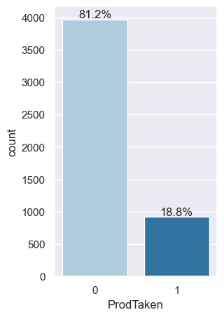

```python
# -----Plot the Bar Chart for the Target Variable: ProdTaken
labeled_barplot(df, "ProdTaken", True, False)
```

*Observations*

- *Only 18.8% of the total customers purchased any of the travel packages.*
- *The plot shows a heavy imbalance in the dataset.*

#### **Univariate Analysis: Numerical Variable**

#### 2) Observations on Age

```
5 Point Summary of Age Attribute:

+-------+-------+------+------+------+-------+
|       |   Min |   Q1 |   Q2 |   Q3 |   Max |
|-------+-------+------+------+------+-------|
| Value |    18 |   31 |   36 |   43 |    61 |
+-------+-------+------+------+------+-------+
```

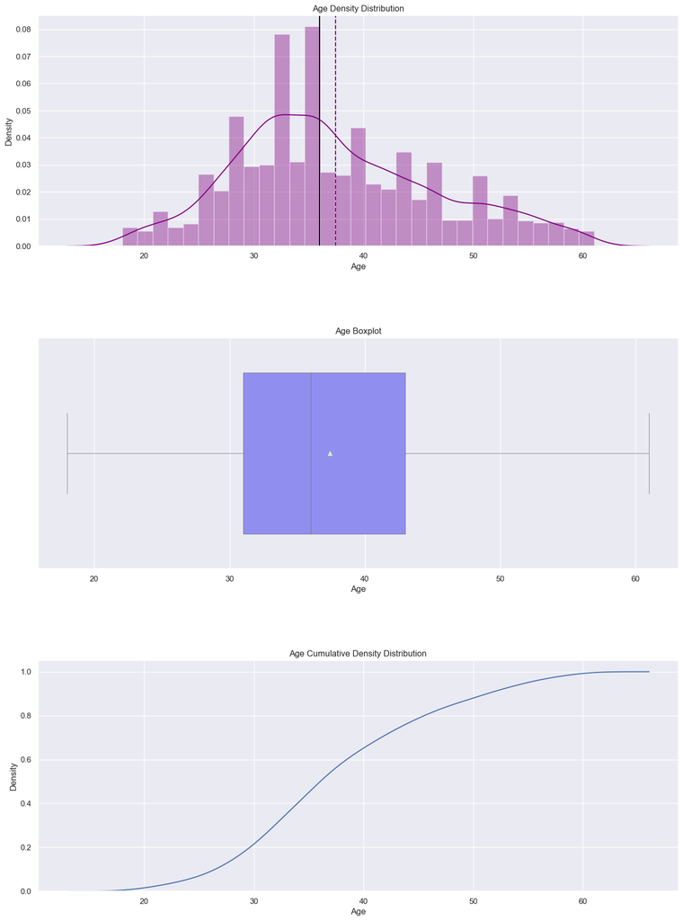

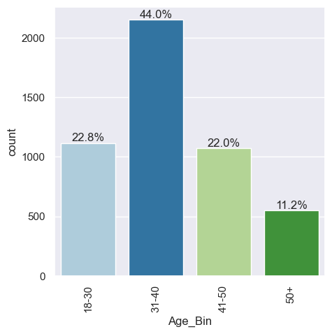

```python
# -----Plot Histogram, Box plot and Cummulative Plot for Age
summary(df, "Age")

# -----Plot the Bar Chart for Age_Bin
labeled_barplot(df, "Age_Bin", True, True)
```

*Observations*

- *`Age` is almost normally distributed with no outliers. we see that most customers are in the age brackets 30- 45 yrs.*
- *There are no outliers*
- *80% of the Customers are 45 yrs and younger.*
- *Most of the Customers (44%) are in the 31-40 `Age` Category.*

#### 3) Observations on Monthly Income

```
5 Point Summary of Monthlyincome Attribute:

+-------+-------+-------+---------+---------+-------+
|       |   Min |    Q1 |      Q2 |      Q3 |   Max |
|-------+-------+-------+---------+---------+-------|
| Value |  1000 | 20485 | 22413.5 | 25424.8 | 98678 |
+-------+-------+-------+---------+---------+-------+
```

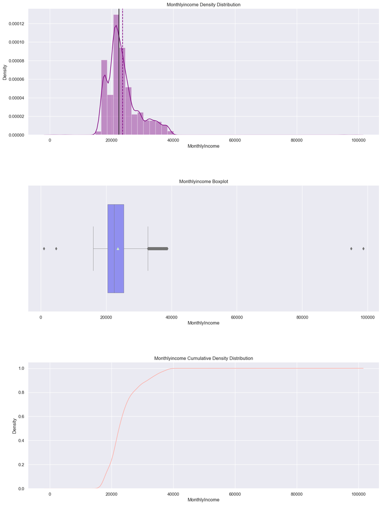

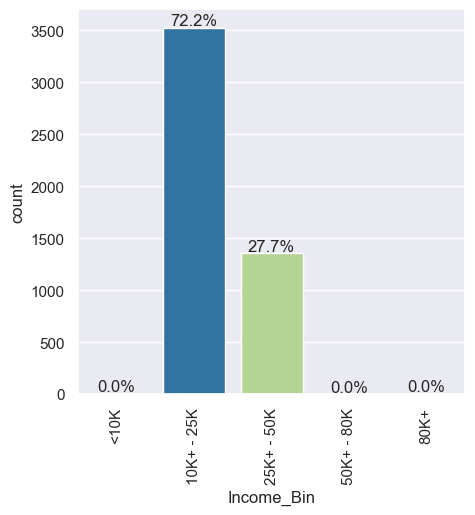

```python
# -----Plot Histogram, Box plot and Cummulative Plot for Monthlylncome
summary(df, "MonthlyIncome")

# -----Plot the Bar Chart for Income_Bin
labeled_barplot(df, "Income_Bin", True, True)
```

*Observations*

- *`MonthlyIncome` is right-skewed.*
- *There are several outliers to the right and a few to the left.*
- *About 80% of the cusomers earn between 20k - 40k*
- *Most of the customers (72%) are in the 10k-25k category.*

#### 4) Observations on Duration of Pitch

```
5 Point Summary of Durationofpitch Attribute:

+-------+-------+------+------+------+-------+
|       |   Min |   Q1 |   Q2 |   Q3 |   Max |
|-------+-------+------+------+------+-------|
| Value |     5 |    9 |   13 |   19 |   127 |
+-------+-------+------+------+------+-------+
```

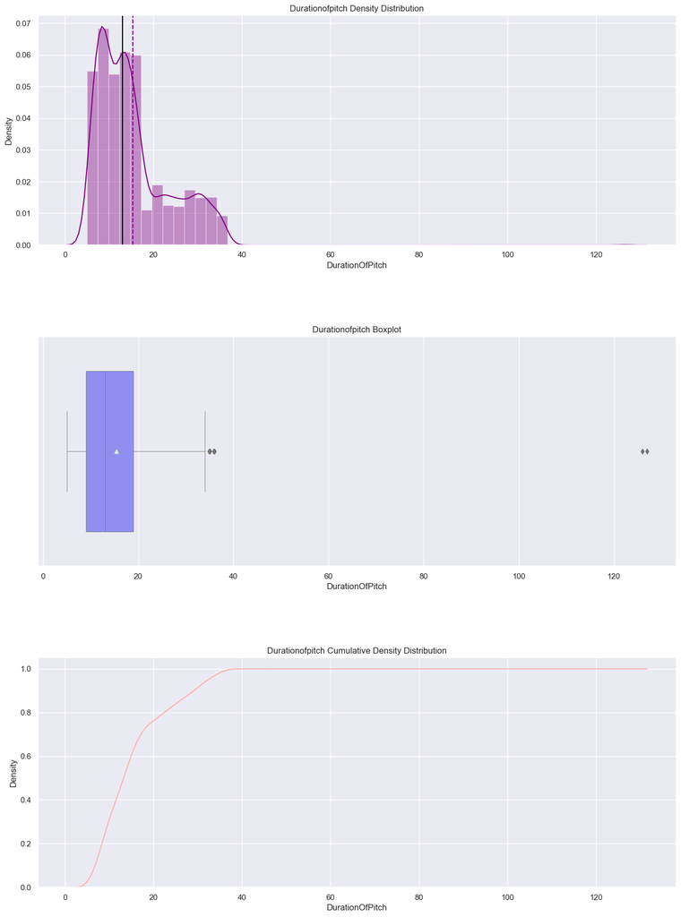

```python
# -----Plot Histogram, Box plot and Cummulative Plot for DurationOfPitch
summary(df, "DurationOfPitch")
```

*Observations*

- *`DurationOfPitch` is right skewed with some extreme right outliers*
- *The max duration is 127 seconds, which, compared to Q3 (20 seconds) is more than 6 times higher*
- *Almost 100% of the pitch lasts for less than 40 seconds

#### 5) Observations on Number of Trips

```
5 Point Summary of Numberoftrips Attribute:

+-------+-------+------+------+------+-------+
|       |   Min |   Q1 |   Q2 |   Q3 |   Max |
|-------+-------+------+------+------+-------|
| Value |     1 |    2 |    3 |    4 |    22 |
+-------+-------+------+------+------+-------+
```

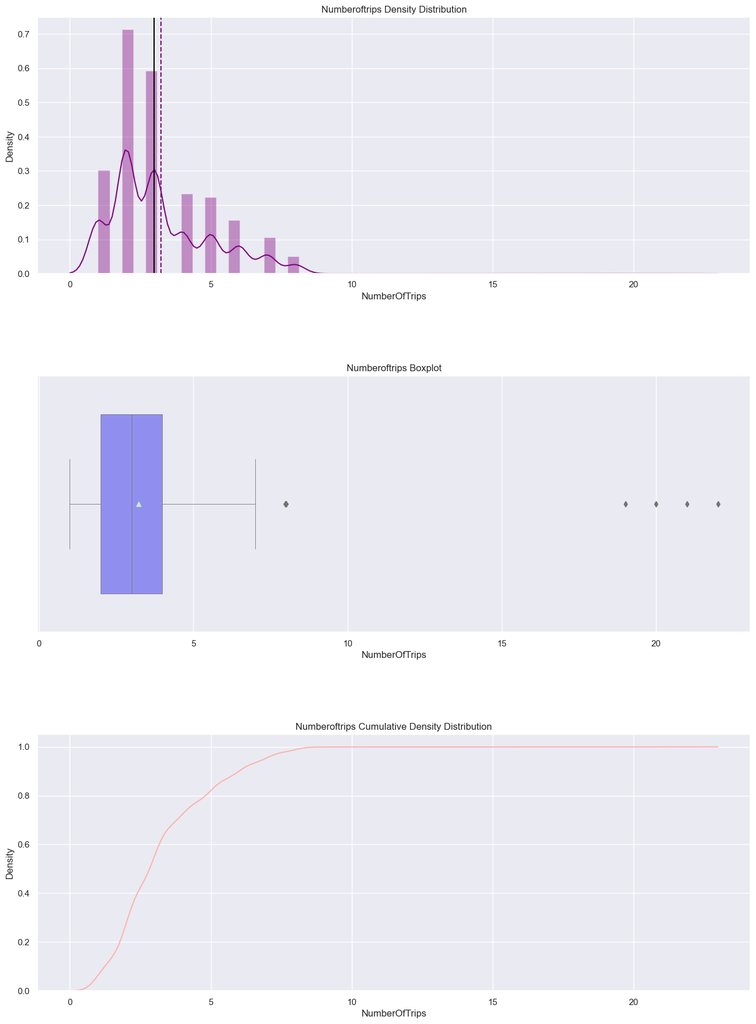

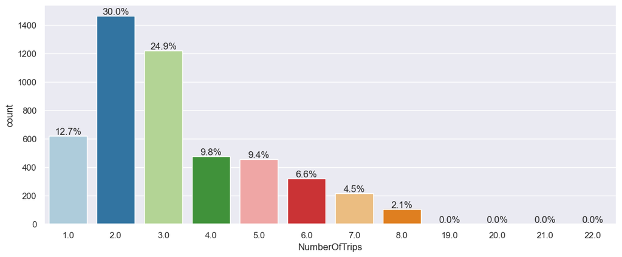

```python
# -----Plot Histogram, Box plot and Cummulative Plot for NumberOfTrips
summary(df, "NumberOfTrips")

# -----Call the label_barplot function to plot the graph
labeled_barplot(df, "NumberOfTrips", True, False)
```

*Observations*

#### 6) Observations on City Tier

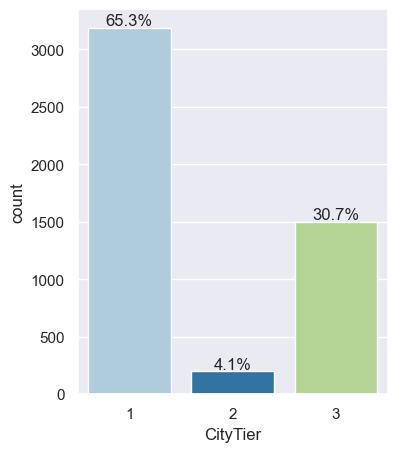

```python
# -----Plot the Bar Chart for CityTier
labeled_barplot(df, "CityTier", True, False)
```

*Observations*

- *65.3% of customers are from Tier 1 cities while 30.7% comes from Tier3 cities*

#### 7) Observations on NumberOfFollowups

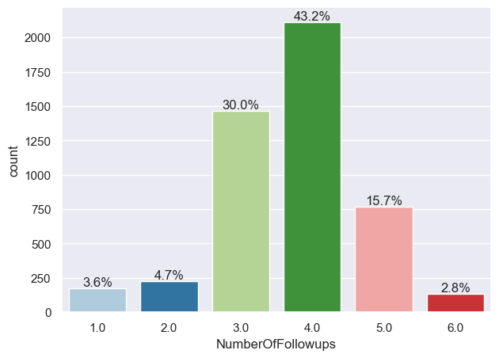

```python
# -----Plot the Bar Chart for NumberOfFollowups
labeled_barplot(df, "NumberOfFollowups", True, False)
```

*Observations*

- *The highest number of followups is 4.0 with 43% followed by 3.0 with 30%.*

#### 8) Observations on ProductPitched

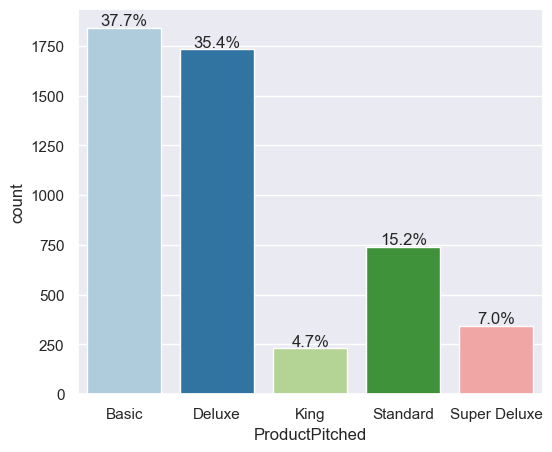

```python
# -----Plot the Bar Chart for ProductPitched
labeled_barplot(df, "ProductPitched", True, False)
```

*Observations*

- *Basic(37.7%) and Deluxe(35.4%) are the most popular travel packages.*
- *The next slightly popular one is the Standard Travel package at 15.2%.*

#### 9) Observations on Number of Person Visiting

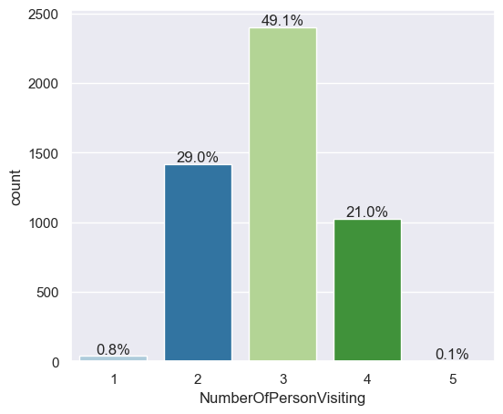

```python
# -----Plot the Bar Chart for NumberOfPersonVisiting
labeled_barplot(df, "NumberOfPersonVisiting", True, False)
```

*Observations*

- *49.1% of customers are taking 3 persons with them during trip.*
- *Around 29% customers want to take 2 persons.*
- *21% customers want to take 4 additional persons with them during their travel.

#### 10) Observations on Occupation

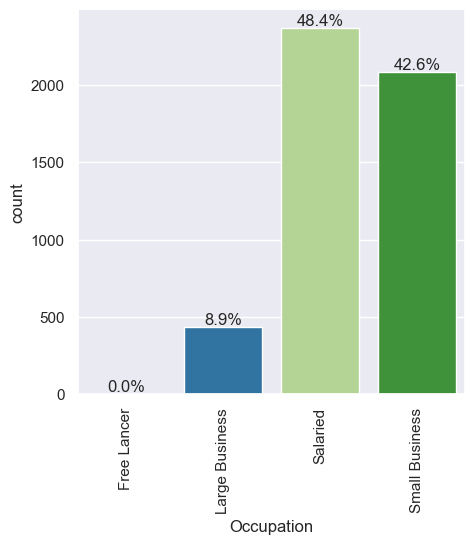

```python
# -----Plot the Bar Chart for ProductPitched
labeled_barplot(df, "Occupation", True, True)
```

*Observations*

- *48.4% of customers are Salaried. Customers with Small Business are the next highest in Occupation at 42.6%.*
- *Salaried and Small Business make up 91% of the customers*
- *There are very few Free Lancers as well.*

#### 11) Observations on Gender

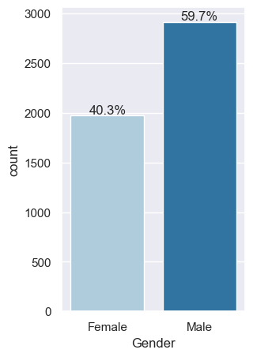

```python
# -----Plot the Bar Chart for Gender
labeled_barplot(df, "Gender", True, False)
```

*Observations*

- *The number of Male customers(59.7%) are higher than Female customers (40.3%)*

#### 12) Observations on Preferred Property Star

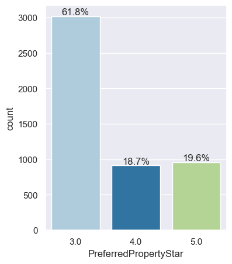

```python
# -----Plot the Bar Chart for PreferredPropertyStar
labeled_barplot(df, "PreferredPropertyStar", True, False)
```

*Observations*

- *61.8% customers prefer a three star rating compared to four (18.7%) and five (19.6%) star ratings*

#### 13) Observations on Marital Status

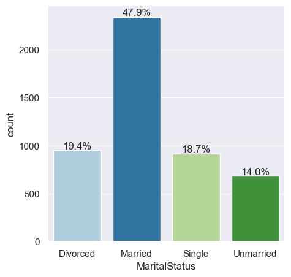

```python
# -----Plot the Bar Chart for MaritalStatus
labeled_barplot(df, "MaritalStatus", True, False)
```

*Observations*

- *Married customers form the bulk of the data at 47.9%.*
- *Divorced (19.4%) and Single (18.7%) coming in close at second and third place.*
- *Unmarried customers with partners form 14% of the data.*

#### 14) Observations on Passport

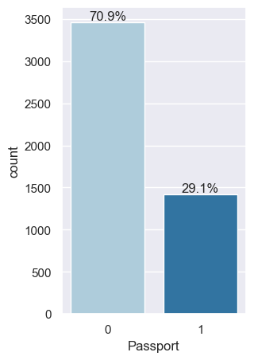

```python
# -----Plot the Bar Chart for Passport
labeled_barplot(df, "Passport", True, False)
```

*Observations*

- *A low 29.1% of customers have a passport*

#### 15) Observations on Pitch Satisfaction Score

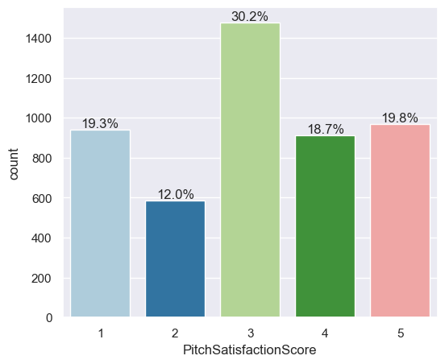

```python
# -----Plot the Bar Chart for PitchSatisfactionScore
labeled_barplot(df, "PitchSatisfactionScore", True, False)
```

*Observations*

- *Only 38.5% of customers rated the Sales Pitch 4 & 5.*
- *30.2% of customers rated the Sales Pitch with a score of 3.*
- *31.3% rated the Sales pitch score at 1&2.*
- *That means that 61.5% rated the Sales Pitch as Poor-Average. This shows an area of huge improvement.*

#### 16) Observations on Designation

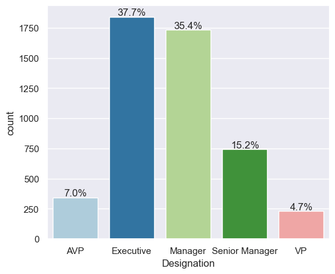

```python
# -----Plot the Bar Chart for Designation
labeled_barplot(df, "Designation", True, False)
```

*Observations*

- *Executive (37.7%) and Manager(35.4%) are the highest Designations of the customers in the dataset.*

#### 17) Observations on Number of Children Visiting

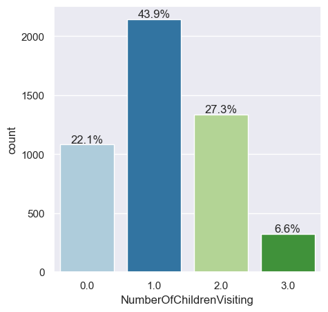

```python
# -----Plot the Bar Chart for NumberOfChildrenVisiting
labeled_barplot(df, "NumberOfChildrenVisiting", True, False)
```

*Observations*

#### 18) Observations on OwnCar

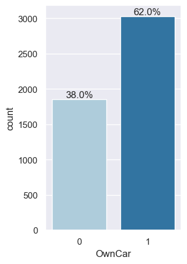

```python
# -----Plot the Bar Chart for OwnCar
labeled_barplot(df, "OwnCar", True, False)
```

*Observations*

- *62% Customers have their own cars*

#### 19) Observations on Type of Contact

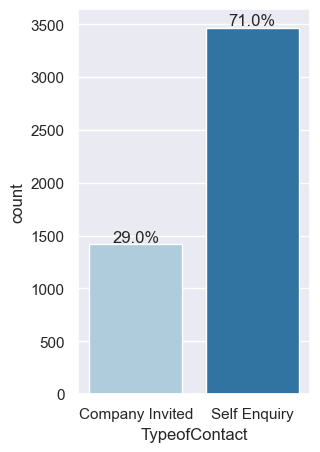

```python
# -----Plot the Bar Chart for TypeofContact
labeled_barplot(df, "TypeofContact", True, False)
```

*Observations*

- *Self-Enquiry is the most preferred contact method by the customers at 71%*

### **Bivariate Analysis**

```python
# -----
# User defined function to plot stacked bar chart
# -----


def stacked_barplot(data, predictor, target):
    """
    Print the category counts and plot a stacked bar chart

    data: dataframe
    predictor: independent variable
    target: target variable
    """
    count = data[predictor].nunique()
    sorter = data[target].value_counts().index[-1]
    tab1 = pd.crosstab(data[predictor], data[target], margins=True).sort_values(
        by=sorter, ascending=False
    )

    print(tab1)
    print("-" * 120)

    sns.set_palette(sns.color_palette("nipy_spectral", 8))
    tab = pd.crosstab(data[predictor], data[target], normalize="index").sort_values(
        by=sorter, ascending=False
    )
    tab.plot(kind="bar", stacked=True, figsize=(count + 5, 6))
    plt.legend(
        loc="lower left",
        frameon=False,
    )
    plt.legend(loc="upper left", bbox_to_anchor=(1, 1))
    plt.show()
```

#### Correllation Matrix

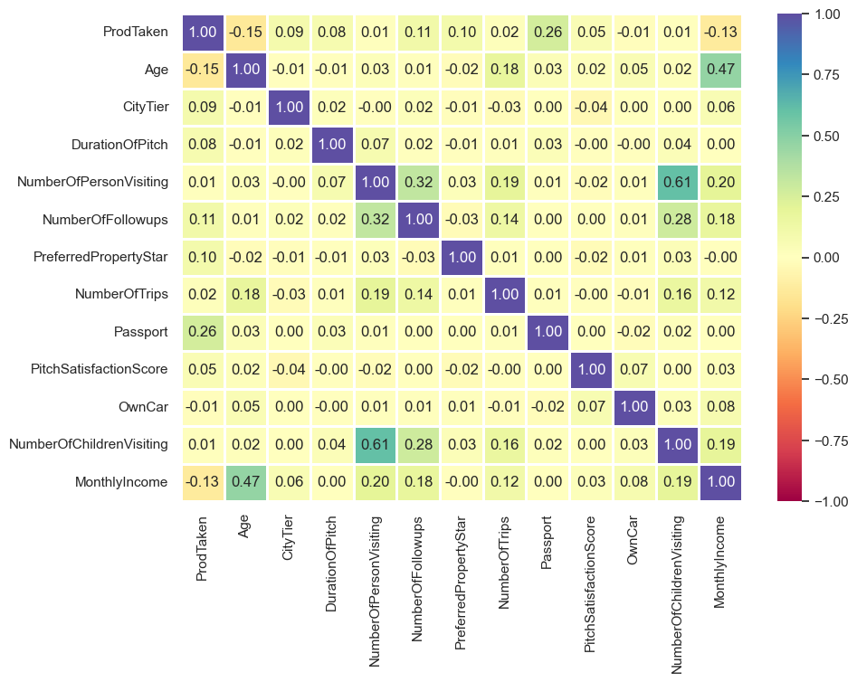

```python
plt.figure(figsize=(10, 7))
sns.heatmap(
    df.corr(), annot=True, vmin=-1, vmax=1, fmt=".2f", cmap="Spectral", linewidths=0.75
)
plt.show()
```

*Observations*

```python
sns.pairplot(df, hue="ProdTaken")
```

[output not shown]

#### Prod Taken vs Number of Person Visiting

```
ProdTaken                  0    1   All
NumberOfPersonVisiting
All                     3968  920  4888
3                       1942  460  2402
2                       1151  267  1418
4                        833  193  1026
1                         39    0    39
5                          3    0     3
------------------------------------------------------------------------------------------------------------------------
```

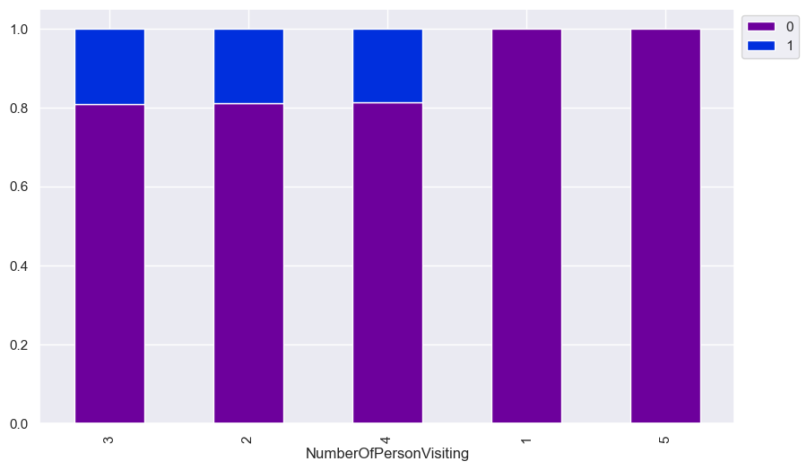

```python
# Stacked Barplot of Prod_Taken in comparison to NumberOfPersonVisiting
stacked_barplot(df, "NumberOfPersonVisiting", "ProdTaken")
```

*Observations*

#### Prod Taken vs Number of Number of Follow ups

```
ProdTaken             0    1   All
NumberOfFollowups
All                3968  920  4888
4.0                1726  387  2113
3.0                1222  244  1466
5.0                 577  191   768
6.0                  82   54   136
2.0                 205   24   229
1.0                 156   20   176
------------------------------------------------------------------------------------------------------------------------
```

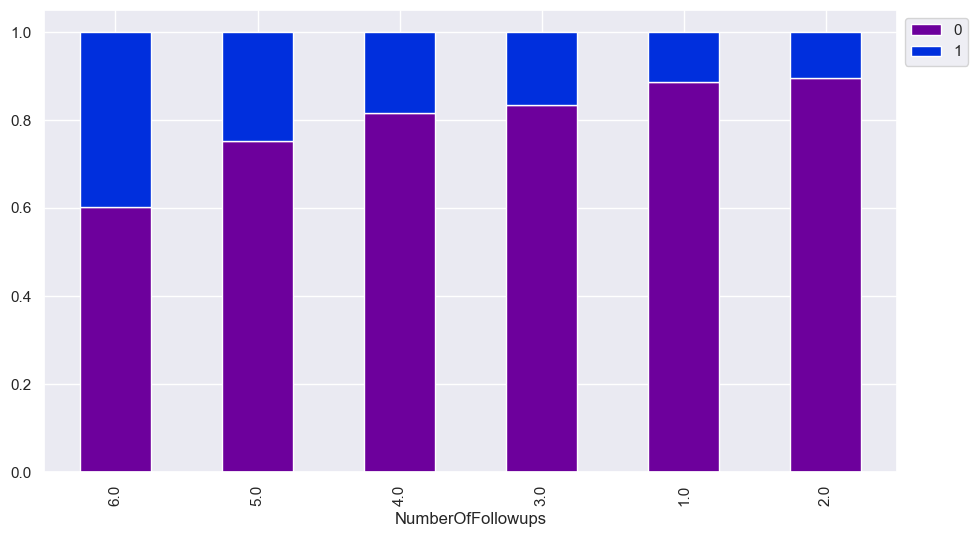

```python
# Stacked Barplot of Prod_Taken in comparison to NumberOfFollowups
stacked_barplot(df, "NumberOfFollowups", "ProdTaken")
```

*Observations*

- *The Business should increase the number of followups in order to increase the number of conversion.*

#### Prod Taken vs Occupation

```
ProdTaken          0    1   All
Occupation
All             3968  920  4888
Salaried        1954  414  2368
Small Business  1700  384  2084
Large Business   314  120   434
Free Lancer        0    2     2
------------------------------------------------------------------------------------------------------------------------
```

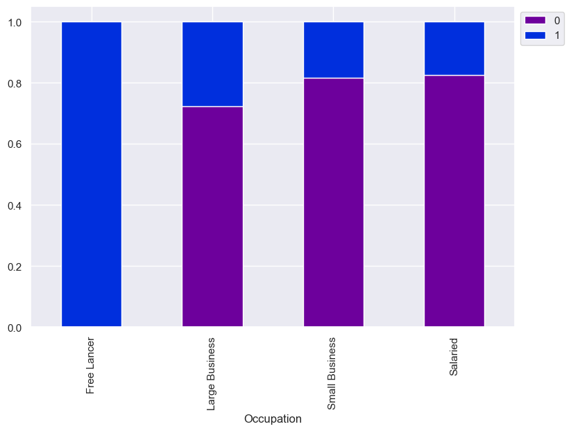

```python
# Stacked Barplot of Prod_Taken in comparison to Occupation
stacked_barplot(df, "Occupation", "ProdTaken")
```

*Observations*

- *100% of Customers who are Freelancers by Occupation bought travel packages. This is understandable as Freelancers have a lot of flexibility. However the sample size is only two.*
- *Out of the 434 Large Business owning customers, about 30% bought travel packages. Among Salaried and Small Business owning customers,close to 20% have bought travel packages.*
- *The Business should target more Freelancers.*

#### Prod Taken vs Marital Status

```
ProdTaken         0    1   All
MaritalStatus
All            3968  920  4888
Married        2014  326  2340
Single          612  304   916
Unmarried       516  166   682
Divorced        826  124   950
------------------------------------------------------------------------------------------------------------------------
```

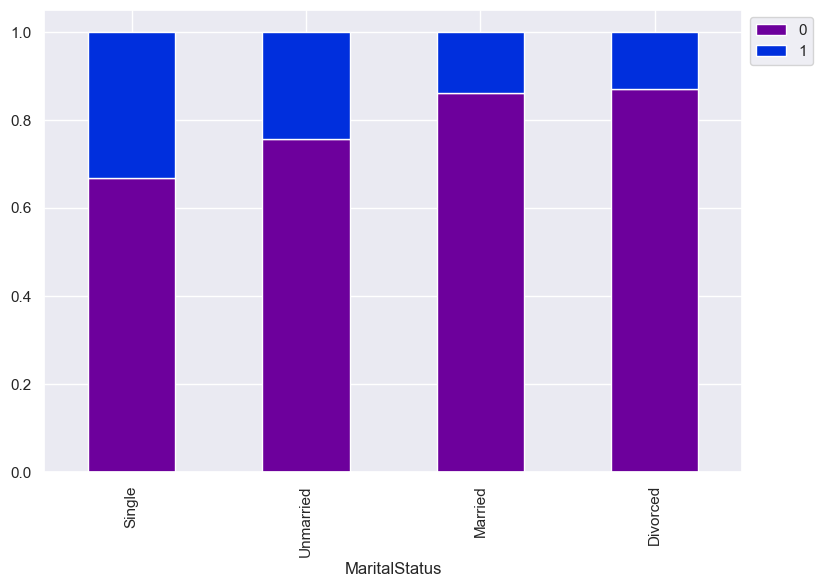

```python
# Stacked Barplot of Prod_Taken in comparison to MaritalStatus
stacked_barplot(df, "MaritalStatus", "ProdTaken")
```

*Observations*

- *Around 30% of all Single customers have bought a product and about 25% of Unmarried customers have also purchased a product.*
- *Almost 50% of the total customers belong to the married category, but we see that only about 15% of them have actually purchased any product.*
- *Again we see flexibility at play. Single and Unmarried are more flexible than Married and Divorced. The Business should target more Singles and unmarried.*
- *The business should look at coming up with a "Family Package" to increase the % of Married customers that signup.*

#### Prod Taken vs Passport

```
ProdTaken     0    1   All
Passport
All        3968  920  4888
1           928  494  1422
0          3040  426  3466
------------------------------------------------------------------------------------------------------------------------
```

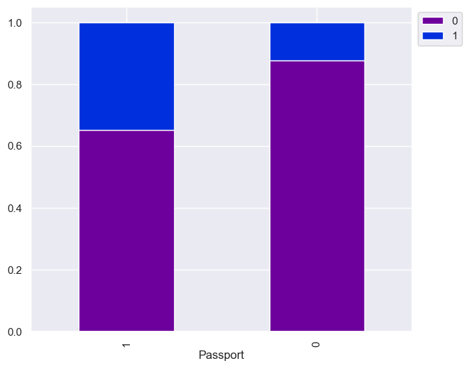

```python
# Stacked Barplot of Prod_Taken in comparison to Passport
stacked_barplot(df, "Passport", "ProdTaken")
```

*Observations*

- *Customers with passport tend to purchase products more than those who don't.*